# R Notebook for Tidy Tuesday

This is an [R Markdown](http://rmarkdown.rstudio.com) Notebook for the [#TidyTuesday](https://github.com/rfordatascience/tidytuesday/blob/master/README.md) challenge: a weekly social data project (in R), which builds off #makeovermonday style projects but aimed at the R ecosystem. An emphasis will be placed on understanding how to summarize and arrange data to make meaningful charts with `ggplot2`, `tidyr`, `dplyr`, and other tools in the `tidyverse` ecosystem.

This code is for Week 2, and my effort to recreate

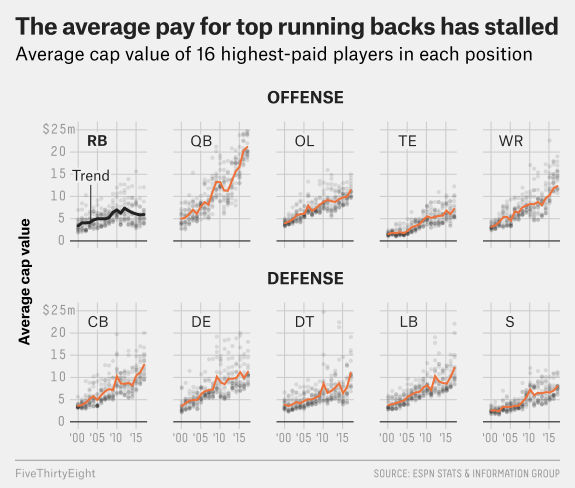

this image, from 538

```r
library(tidyverse, quietly = TRUE, warn.conflicts = FALSE)
library(readxl) # To read in Excel data the tidyverse way
```

# import data

```r
football <- read_excel("data/tidy_tuesday_week2.xlsx")
football
```

| year | Cornerback | Defensive Lineman | Linebacker | Offensive Lineman | Quarterback | Running Back | Safety | Special Teamer | Tight End | Wide Receiver |
| --- | --- | --- | --- | --- | --- | --- | --- | --- | --- | --- |
| 2011 | 11265916 | 17818000 | 16420000 | 15960000 | 17228125 | 12955000 | 8871428 | 4300000 | 8734375 | 16250000 |
| 2011 | 11000000 | 16200000 | 15623000 | 12800000 | 16000000 | 10873833 | 8787500 | 3725000 | 8591000 | 14175000 |
| 2011 | 10000000 | 12476000 | 11825000 | 11767500 | 14400000 | 9479000 | 8282500 | 3556176 | 8290000 | 11424000 |
| 2011 | 10000000 | 11904706 | 10083333 | 10358200 | 14100000 | 7700000 | 8000000 | 3500000 | 7723333 | 11415000 |
| 2011 | 10000000 | 11762782 | 10020000 | 10000000 | 13510000 | 7500000 | 7804333 | 3250000 | 6974666 | 10800000 |
| 2011 | 9244117 | 11340000 | 8150000 | 9859166 | 13250000 | 7033000 | 7652700 | 3225000 | 6133333 | 9993750 |
| 2011 | 8000000 | 10000000 | 7812500 | 9500000 | 12950000 | 6750000 | 7550000 | 2900000 | 5962500 | 8605200 |
| 2011 | 7900000 | 9482500 | 7700000 | 9420000 | 12574700 | 6370002 | 7500000 | 2850000 | 4687500 | 8273333 |
| 2011 | 7400000 | 8450000 | 7200000 | 8880000 | 12465000 | 6000000 | 5745000 | 2600000 | 4536666 | 7827500 |
| 2011 | 7000000 | 8383266 | 7100000 | 8686750 | 11320000 | 4933333 | 5250000 | 2600000 | 4200000 | 7531250 |

[output cut: 790 more lines]

# tidydata, and match names with labels

```r
football_adj <- football %>%
  rename(QB = Quarterback, RB = `Running Back`, S = Safety, ST = `Special Teamer`, TE = `Tight End`, WR = `Wide Receiver`, CB = Cornerback, DL = `Defensive Lineman`, LB = Linebacker, OL = `Offensive Lineman`)
```

# mutate data to divide by 1M

```r
football_adj <- football_adj %>%
  mutate_at(vars(CB:WR), funs(. / 1000000))
```

# select top 16 salares of each year, for each position

```r
football_16 <- football_adj %>%
  group_by(year) %>%
  top_n(16) %>%
  gather(key = position, value = salary, -year)
football_16
```

| year | position | salary |
| --- | --- | --- |
| 2011 | CB | 11.265916 |
| 2011 | CB | 11.000000 |
| 2011 | CB | 10.000000 |
| 2011 | CB | 10.000000 |
| 2011 | CB | 10.000000 |
| 2011 | CB | 9.244117 |
| 2011 | CB | 8.000000 |
| 2011 | CB | 7.900000 |
| 2011 | CB | 7.400000 |
| 2011 | CB | 7.000000 |

[output cut: 1280 more lines]

# find means for line graph

Here is a code block in that I ultimately didn’t, but thought I would. The image looked like a smooth fit mean line would ‘fit’ each of the years, so made an ‘avg’ df that I anticipated using. When I was bulidng the ggplot code block (below), discovered that ggplot would do this for me. Thanks ggplot!

```r
football_16_avg <- football_adj %>%
  group_by(year) %>%
  top_n(16) %>%
  summarise_each(funs(mean))
```

```
## `summarise_each()` is deprecated.
## Use `summarise_all()`, `summarise_at()` or `summarise_if()` instead.
## To map `funs` over all variables, use `summarise_all()`
```

```r
football_16_avg
```

| year | CB | DL | LB | OL | QB | RB | S | ST | TE | WR |
| --- | --- | --- | --- | --- | --- | --- | --- | --- | --- | --- |
| 2011 | 8.115992 | 9.994052 | 8.822281 | 9.680655 | 11.65077 | 6.472970 | 6.245549 | 2.898823 | 5.441586 | 8.683837 |
| 2012 | 8.623332 | 10.453700 | 10.940695 | 9.355170 | 11.19972 | 7.438842 | 6.666313 | 3.320667 | 5.496884 | 9.364248 |
| 2013 | 8.546598 | 10.424048 | 9.680041 | 8.817781 | 13.44241 | 6.725370 | 6.410209 | 3.228406 | 5.601911 | 8.131698 |
| 2014 | 8.209990 | 12.134125 | 9.010593 | 9.418958 | 15.64211 | 6.421687 | 6.720450 | 3.329132 | 5.601758 | 9.567089 |
| 2015 | 10.254360 | 11.304972 | 8.587793 | 9.659186 | 16.24157 | 5.742327 | 6.485066 | 3.309917 | 6.359610 | 10.086624 |
| 2016 | 11.119392 | 10.986636 | 10.152284 | 9.953855 | 20.03880 | 5.849268 | 7.071554 | 3.561917 | 6.025905 | 11.856795 |
| 2017 | 11.542823 | 12.974684 | 12.179928 | 11.666841 | 19.91043 | 5.985936 | 7.375973 | 3.782500 | 7.294017 | 12.695158 |
| 2018 | 12.343404 | 15.953453 | 12.490899 | 12.528991 | 23.80932 | 6.381291 | 9.025292 | 3.816764 | 7.650108 | 13.198333 |

# need to get a mean for each year and each position (probably put in new df so you can add it as a ggplot element)

Wasn’t sure how to do this, so skipped it; but again, didn’t need to.

# plot

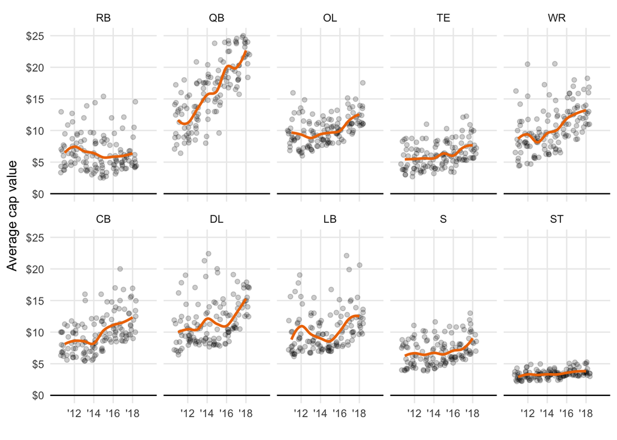

```r
football_16$position_f = factor(football_16$position, levels=c('RB', 'QB', 'OL', 'TE', 'WR', 'CB', 'DL', 'LB', 'S', 'ST'))

ggplot(football_16) +
  geom_jitter(aes(x = year, y = salary), alpha = 0.2) +
  geom_smooth(aes(x = year, y = salary), color = "darkorange2", method = "auto", span = 0.4, se = FALSE) +
  #coord_cartesian(ylim = c(0,25), xlim = c(2010,2020)) +
  scale_y_continuous(limits = c(0,25), breaks=c(0,5,10,15,20,25), minor_breaks = NULL, labels = scales::dollar) +
  scale_x_continuous(limits = c(2010,2020), breaks = c(2012,2014,2016,2018), minor_breaks = NULL, label = c("'12", "'14", "'16", "'18")) +
  geom_hline(aes(yintercept = 0)) +
  facet_wrap(~ position_f, ncol = 5) +
  theme_minimal() +
  labs(y = "Average cap value", x = "")
```

# save

```r
ggsave("nfl_salary.png", last_plot(), height = 8, width = 12, units = "in", dpi = 600)
#default is last plot, but can name objects here
```

# Conclusion

First step was to make an outline of anticipated steps to go from raw data to final image; I made these key headers of each section, and then began to work my way through. Ultimately I didn’t need two of the anticipated steps. Here are some of the new things that I needed to learn/figure out for the final image:

- ggplot
- factor
- top_n (to select top #)
- mutate_at (to make a new df)
- gather(key = position, value = salary, -year)
- [ggsave](http://ggplot2.tidyverse.org/reference/ggsave.html)

This was the closest that I’ve gotten to making the image look even remotely close; so needless to say, I’m hooked.